# Modeling Titanic deaths

# Abstract

In this document I will explain the predictions of our XGBoost model using the great XGBoost Explainer package. More info about the package can be found in [this great article](https://medium.com/applied-data-science/new-r-package-the-xgboost-explainer-51dd7d1aa211) or in its [Gihub repo](https://github.com/AppliedDataSciencePartners/xgboostExplainer/tree/master/R).

Let’s begin!

# Load libraries and read data

```r
library(data.table)
library(xgboost)
library(xgboostExplainer)
library(magrittr)
library(ggplot2)
library(Matrix)
```

```r
load("../../../0-model-to-explain/xgboost-titanic.RData")
```

# Explain some predictions

Until now, we could only extract the general feature importance:

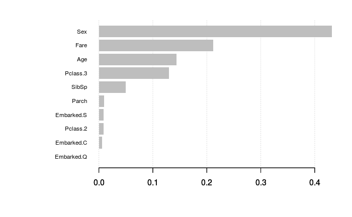

```r
col_names <- colnames(preprocessed_training_set)
col_names[col_names == "male"] <- "Sex"
imp <- xgb.importance(col_names, xgb_model)
xgb.plot.importance(imp)
```

But now we can go much further!! We are able to explain why the XGBoost model made a particular prediction.

Let’s build the explainer:

```r
explainer <- buildExplainer(xgb.model = xgb_model,
                            trainingData = training_set_xgb,
                            type = "binary")
```

```
Creating the trees of the xgboost model...
Getting the leaf nodes for the training set observations...
Building the Explainer...
STEP 1 of 2

Recalculating the cover for each non-leaf...


Finding the stats for the xgboost trees...


STEP 2 of 2

Getting breakdown for each leaf of each tree...


DONE!
```

Let’s plot some waterfalls:

```
Extracting the breakdown of each prediction...


DONE!

Prediction:  0.1678202
Weight:  -1.601155
Breakdown
 intercept       male        Age       Fare Embarked.C      other
-0.5806002 -0.9618095  0.5189193 -0.3366921 -0.1179851 -0.1229879
```

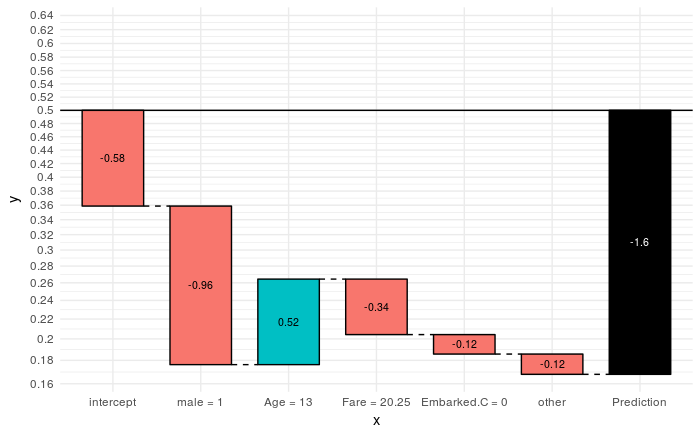

```r
test_set_xgb <- xgb.DMatrix(data = preprocessed_test_set)
showWaterfall(xgb.model = xgb_model, explainer = explainer, DMatrix = test_set_xgb,
              data.matrix = preprocessed_test_set, idx = 1, type = "binary", threshold = 0.1) +
  theme_minimal()
```

Another interesting detail is the “other” bar. We can set a threshold in **showWaterfall** so that any feature with influence less than the threshold won’t be shown, and will be grouped in the *other* column.

Let’s explain other passenger’s prediction:

```
Extracting the breakdown of each prediction...


DONE!

Prediction:  0.7645533
Weight:  1.177807
Breakdown
  intercept        male    Pclass.3  Embarked.S        Fare         Age       other
-0.58060020  1.76430354 -1.18890783  0.46475311  0.36056802  0.30627693  0.05141338
```

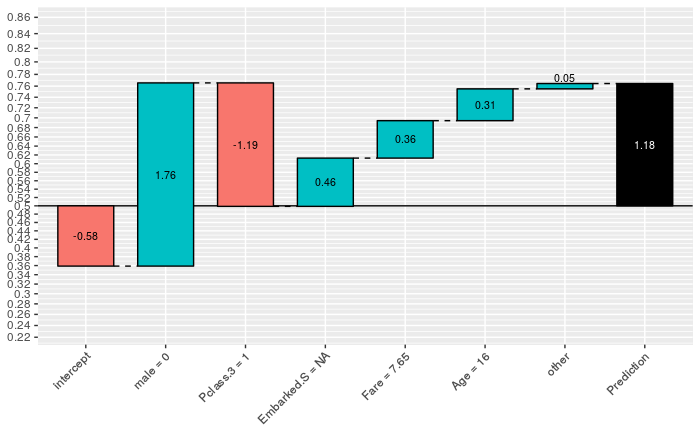

```r
showWaterfall(xgb.model = xgb_model, explainer = explainer, DMatrix = test_set_xgb,
              data.matrix = preprocessed_test_set, idx = 2, type = "binary", threshold = 0.1)
```

In this case we have a woman. She travels in 3rd class, but being a woman and being young probably saved her (id did, according to our model). It is interesting (and strange) to see that, in this particular case, a low Fare helped her to survive.

```r
prediction_breakdown <- explainPredictions(xgb.model = xgb_model,
                                           explainer = explainer,
                                           data = preprocessed_test_set)
```

```
Extracting the breakdown of each prediction...


DONE!
```

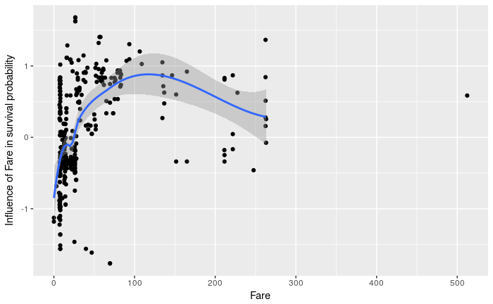

```r
ggplot() +
  geom_point(aes(test_set$Fare, prediction_breakdown$Fare)) +
  geom_smooth(aes(test_set$Fare[test_set$Fare < 500], prediction_breakdown$Fare[test_set$Fare < 500])) +
  labs(x = "Fare", y = "Influence of Fare in survival probability")
```

There is a clear relationship between the paid Fare and the influence of the Fare in survival probability, according to the model. The higher the Fare, the more positive the influence of Fare in the probability of surviving. At least until reaching a Fare of 100. After that, the influence is still positive, but Fare gets less important than other features.

We can use this kind of plots to compare feature importance. Let’s see the Age influence:

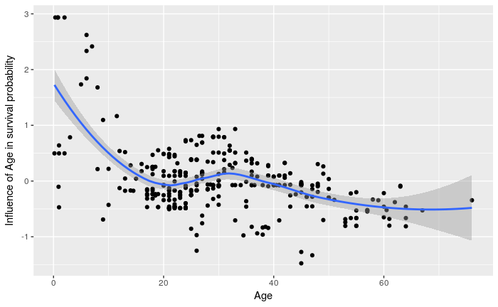

```r
ggplot() +
  geom_point(aes(test_set$Age, prediction_breakdown$Age)) +
  geom_smooth(aes(test_set$Age, prediction_breakdown$Age), method = "loess") +
  labs(x = "Age", y = "Influence of Age in survival probability")
```

We see that the Age has a huge positive impact for people under 10, has a null mean impact between 20 and 40, and has a slight negative impact after 40.

We can also see cross influence between variables. For example, we can see how Age influences the importance of Fare in survival probability:

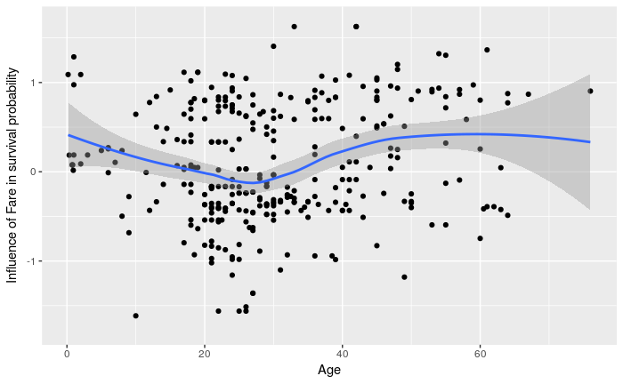

```r
ggplot() +
  geom_point(aes(test_set$Age, prediction_breakdown$Fare)) +
  geom_smooth(aes(test_set$Age, prediction_breakdown$Fare), method = "loess") +
  labs(x = "Age", y = "Influence of Fare in survival probability")
```

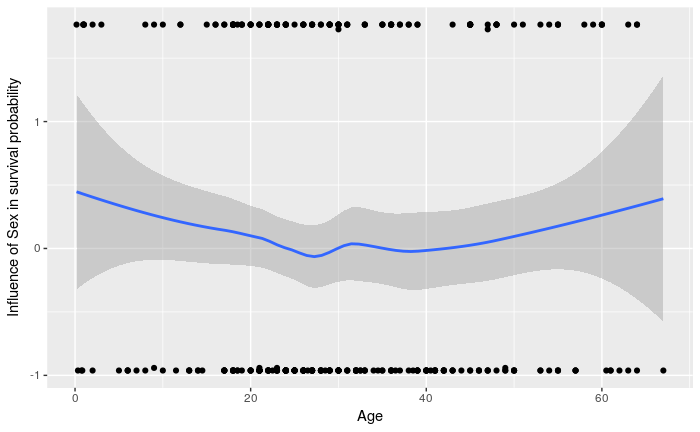

```r
ggplot() +
  geom_point(aes(test_set$Age[test_set$Age < 70],
                 prediction_breakdown$male[test_set$Age < 70])) +
  geom_smooth(aes(test_set$Age[test_set$Age < 70],
                  prediction_breakdown$male[test_set$Age < 70]),
              method = "loess") +
  labs(x = "Age", y = "Influence of Sex in survival probability")
```

We don’t have enough data to extract conclusions. But this tool is great!!